# Compare Network Stats Across Ports

Preparation for network analysis in CCIEA ESR

M. Fisher, J. Samhouri

Written Dec 30, 2021. Last Run 2022-01-14

# Description

This document graphs network metrics by port group for the US West Coast.

The two core network metrics are:

1. Node Strength
2. Eigen Vector Centrality.

# Setup

This script requires the following packages.

```r
if(!require("tidyverse")) {install.packages("tidyverse")}
if(!require("foreign")) {install.packages("foreign")}
if(!require("lubridate")) {install.packages("lubridate")}
if(!require("facetscales")) {devtools::install_github("zeehio/facetscales"); library(facetscales)}
if(!require("ggplot2")) {install.packages("ggplot2")}
if(!require("grid")) {install.packages("grid")}
if(!require("gridExtra")) {install.packages("gridExtra")}
if(!require("ggpubr")) {install.packages("ggpubr")}
if(!require("cowplot")) {install.packages("cowplot")}
if(!require("PNWColors")) {devtools::install_github("jakelawler/PNWColors"); library(PNWColors)}
```

Select your directories.

```r
## directory with network statistics
indir <- 'results/statistics'

## directory with port group lookup key
indir2 <- 'data/input'

## directory to save figures
pngdir <- 'results/figures'
```

What are the names of the `.csv` files with the network statistics that you want to compare? Would not suggest listing more than 4. Files should all be in the input directory (`indir`) specified above.

```r
filenames <- c("VesselLevelNodeStats_2004_2020_21pcgroups_totalrev5000_indivrev500_connectivity_rmCrab_10pContribution.csv")

port_filename <- 'iopac_conversion_table.csv'

#"VesselLevelNetworkStats_2004_2020_21pcgroups_totalrev5000_indivrev500_connectivity_rmCrab_10pContribution.csv")
```

Provide descriptive names to differentiate the datasets drawn from the files listed above.

```r
dataset_names <- c("NodeStats")

#"NetworkStats")
```

Specify which network metrics to retain from the full data set.

```r
node_metrics <- c('node_strength','eigen')
```

Specify which fisheries to retain from the full data set.

```r
myfisheries <- c('Non-DTS groundfish')
```

Specify which port groups to retain from the full data set. Focus on all CA and OR port groups

```r
# 01-06-22: note jameal updated OSD, SD, and SDA ports to have the same lat long as OCN. Amanda P has made the same fix. Also reassigned MCR to the Eureka IOPAC port group,  Amanda P agreed with this change
iopac_lookup <- read_csv(here::here(indir2, port_filename))
ca_or_ports <- iopac_lookup %>% filter(`Agency Name` != "WDFW") %>% select(IOPAC) %>% distinct() %>% pull()

or_ports <- iopac_lookup %>% filter(`Agency Name` == "ODFW") %>% select(IOPAC) %>% distinct() %>% pull()

morrobaymaxlat <- iopac_lookup %>% filter(IOPAC == "Morro Bay") %>% summarise(maxlat = max(PACFIN_LAT)) %>% pull()

nca_ports <- iopac_lookup %>% filter(`Agency Name` == "CDFW" & PACFIN_LAT > morrobaymaxlat) %>% select(IOPAC) %>% distinct() %>% pull()

sca_ports <- iopac_lookup %>% filter(`Agency Name` == "CDFW" & PACFIN_LAT <= morrobaymaxlat) %>% select(IOPAC) %>% distinct() %>% pull()
```

# Read in Data

Network metrics from different datasets.

```r
for(i in seq(1,length(filenames))){
  tmpdat <- read.csv(here::here(indir, filenames[i])) %>%
    dplyr::select(pcgroup, year, metier.cm, all_of(node_metrics)) %>%
    filter(pcgroup %in% ca_or_ports) %>%
    filter(metier.cm %in% myfisheries) %>%
    mutate(dataset=dataset_names[i])
  if(i==1){
    dat <- tmpdat
  } else{ dat <- bind_rows(dat,tmpdat)}
}

head(dat)
```

|  | pcgroup | year | metier.cm | node_strength | eigen | dataset |
| --- | --- | --- | --- | --- | --- | --- |
| 1 | Astoria | 2004 | Non-DTS groundfish | 0.4844245 | 0.9467139 | NodeStats |
| 2 | Tillamook | 2004 | Non-DTS groundfish | 0.1034818 | 0.1333745 | NodeStats |
| 3 | Brookings | 2004 | Non-DTS groundfish | 0.2067034 | 0.3264512 | NodeStats |
| 4 | Crescent City | 2004 | Non-DTS groundfish | 0.4846610 | 0.6835458 | NodeStats |
| 5 | Morro Bay | 2004 | Non-DTS groundfish | 0.5501432 | 0.9336953 | NodeStats |
| 6 | Fort Bragg | 2004 | Non-DTS groundfish | 0.2840287 | 0.4882373 | NodeStats |

Check to make sure that all of the datasets were read in.

```
##            pcgroup
## dataset     Astoria Bodega Bay Brookings Coos Bay Crescent City Eureka
##   NodeStats      14         12        17        8            16      8
##            pcgroup
## dataset     Fort Bragg Los Angeles Monterey Morro Bay Newport San Diego
##   NodeStats         16           9       16        17       4         2
##            pcgroup
## dataset     San Francisco Santa Barbara Tillamook
##   NodeStats            15             5        17
```

Pivot longer to graph multiple metrics at once.

```r
dat_long <- dat %>%
  pivot_longer(cols=c(all_of(node_metrics)), names_to = "metric", values_to = "value")
```

Clean up metric names.

```r
dat_long$metric <- recode(dat_long$metric,
                          node_strength = "Node Strength",
                          eigen = "Importance")
#dat_long$metric <- factor(dat_long$metric, levels=c("Size", "Edge Density","Mean Degree", "Central.", "Central. (UnW)", "Mod.", "Mod. (UnW)"))

nonDTSports_sorted <- dat_long %>% left_join(iopac_lookup %>% select(IOPAC, PACFIN_LAT), by = c('pcgroup' = 'IOPAC')) %>% select(pcgroup, PACFIN_LAT) %>% group_by(pcgroup) %>% summarise(lat = mean(PACFIN_LAT)) %>% arrange(lat) %>% select(pcgroup) %>% pull() # use arrange(-lat) if coord_flip() is NOT used

dat_long$pcgroup <- factor(dat_long$pcgroup, levels=nonDTSports_sorted)
```

# 2. Graph Box Plots

Make OR, NCA, SCA data frames and color palettes.

Make OR plot

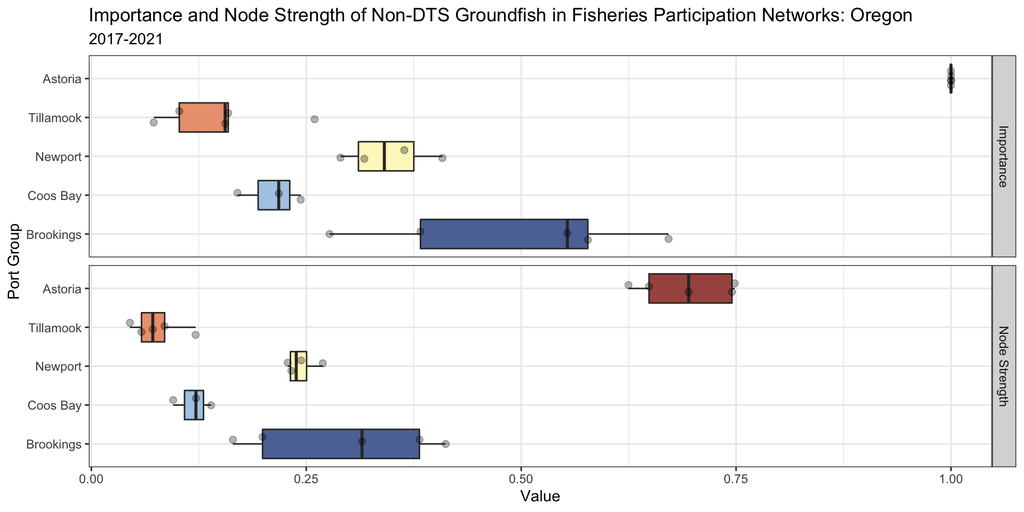

Make NCA plot

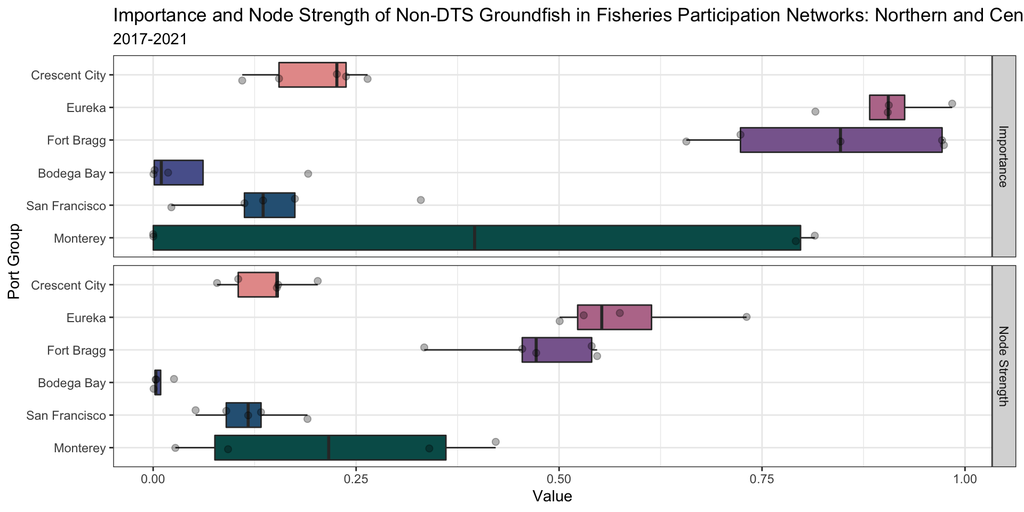

Make SCA plot

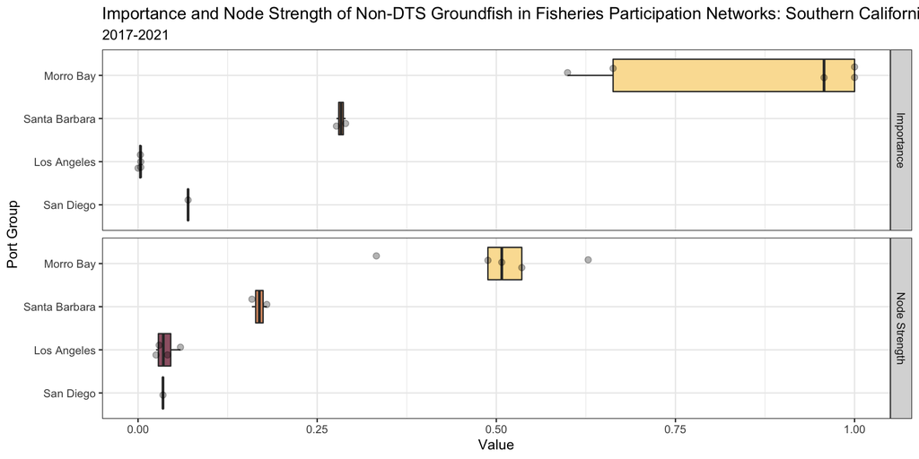

Save plots as pngs, with filename: State. Importance and Node Strength of Non-DTS Groundfish in Fisheries Participation Networks 2017-2021.png

Focus on node strength only, compile into a single figure. Save plot as png, with filename: Node Strength of Non-DTS Groundfish in Fisheries Participation Networks 2017-2021, Oregon and California.png

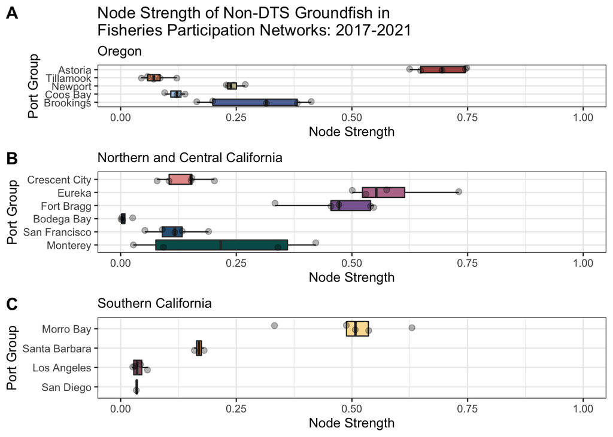